Assigned on Friday, 27 April 2018, due 21:00 on Sunday, 13 May 2018

Solve the following three problems beneath each question. Compress Rmd, html, and any data files you may create into a single zip file. Name the zip file with your Bilkent student ID (e.g., 21400023.zip). Upload the zip file to the [IE 553 moodle page](https://moodle.bilkent.edu.tr/2017-2018-spring/).

0. Read Chapters 2, 3, and Sections 4.1, 4.2 of Chapter 4.
1. Find the scale weights.
   1. A grocer can measure the exact weight of anything weighing between 1 and 40 grams (integers only) in his store with his scale and four scale weights. What can those four scale weights be? (E. Halıcı, Zeka Oyunları, 1. Kitap, TÜBİTAK Popüler Bilim Kitapları, page 40).

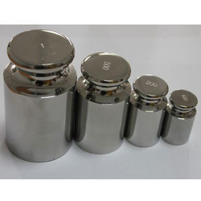

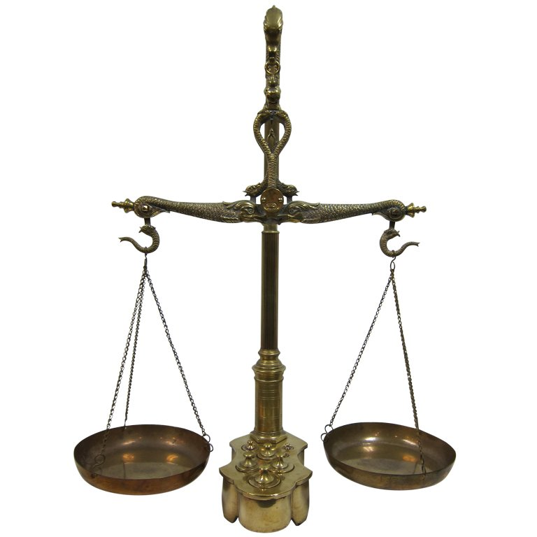

      Figure 1: Standard weights and a scale

      Hint: Can this be formulated as a regression problem?
   2. Another grocer can weigh anything with a weight between 1 and 364 grams (integers only) using a scale and six scale weights. What can those six scale weights be?
2. Do Exercise 2 at the end of Chapter 2.
3. Do Exercise 3 at the end of Chapter 3.
4. Do Exercise 2 at the end of Chapter 4.